# BE1 dataset quality control using DropletQC

Author

Valerio Reffo

Published

June 6, 2028

```r
library(DropletQC)
library(purrr)
library(ggplot2)
library(patchwork)
library(dplyr)
library(scuttle)
library(scran)
library(scater)
library(anndataR)
library(SingleCellExperiment)
```

## Data Loading and Nuclear Fraction Integration

We define the sample IDs and import the RDS files containing the nuclear fraction calculated for each individual sample, then map them back to the main `SingleCellExperiment` object.

```r
samples <- c("A549", "CCL-185-IG", "PC9", "CRL5868", "HTB178", "DV90", "HCC78", "PBMCs")

# 1. Load the list of nuclear fractions
nf_list <- imap(samples, \(sample, name) {
  s_path <- paste0("~/scFound_bench/results/nf_BE1_", sample, ".rds")
  readRDS(s_path)
})
names(nf_list) <- samples
```

```r
sce_be1 <- readRDS("/projects/shared/intronic_bam/datasets/BE1/BE1_sce.RDS")
sce_be1
```

```
class: SingleCellExperiment
dim: 36753 29128
metadata(8): Samples Samples ... Samples Samples
assays(2): counts logcounts
rownames(36753): MIR1302-2HG FAM138A ... CMO311 CMO312
rowData names(4): ID Symbol Type gene_names
colnames(29128): AAACCCAAGCCTATCA-1_A549 AAACCCAAGCGAGAAA-1_A549 ...
  TTTGTTGTCAGTAGGG-1_PC9 TTTGTTGTCTTCGGAA-1_PC9
colData names(14): Sample Barcode ... cell_status cell_id
reducedDimNames(6): PCA UMAP ... GeneFormer UMAP_GeneFormer
mainExpName: NULL
altExpNames(0):
```

#### scGPT embeddings

Let’s read the anndata with the embeddings matrix

```r
be_ann <- read_h5ad("/projects/shared/intronic_bam/datasets/anndata/be1_scGPT_embeddings.h5ad")
```

Add it into the reducedDim slot of the sce

```r
scgpt_matrix <- as.matrix(be_ann$obsm['X_scGPT']$X_scGPT)
scgpt_matrix_aligned <- scgpt_matrix[colnames(sce_be1), ]
reducedDim(sce_be1, "scGPT") <- scgpt_matrix_aligned
```

#### GeneFormer embeddings

```r
emb_gf <-readr::read_csv("/projects/shared/intronic_bam/datasets/embeddings/geneformer/be1_geneformer.csv")
```

Add it into the reduced dims of the sce

```r
reducedDim(sce_be1, "GeneFormer") <- emb_gf[match(as.character(colnames(sce_be1)), as.character(emb_gf$Barcode)), ] |>
  select(where(is.numeric), -any_of(c("Unnamed: 0", "...1"))) |>
  as.matrix() |>
  `rownames<-`(as.character(colnames(sce_be1)))
```

### Mapping Nuclear Fraction to `colData`

We merge the individual nuclear fraction data frames into a single object, ensuring that the constructed cell keys perfectly match the `colnames` of our SCE object.

```r
# Combine the list into a single data frame
nf_combined <- do.call(rbind, lapply(names(nf_list), function(s) {
  df <- as.data.frame(nf_list[[s]])
  # Create a cell key identical to sce_be1 colnames (e.g., "AAACCCAAGCCTATCA-1_A549")
  df$cell_key <- paste0(rownames(df), "_", s)
  return(df)
}))

# Safe mapping using match()
colData(sce_be1)$nuclear_fraction <- nf_combined$nuclear_fraction[match(colnames(sce_be1), nf_combined$cell_key)]

# Verify the integration
head(colData(sce_be1)[, c("Sample", "Barcode", "nuclear_fraction")])
table(sce_be1$Sample)
```

[output not shown]

## Exploratory Analysis

We visualize the distribution of the nuclear fraction across different samples and explore its relationship with total UMI counts to identify potential ambient background or empty droplets.

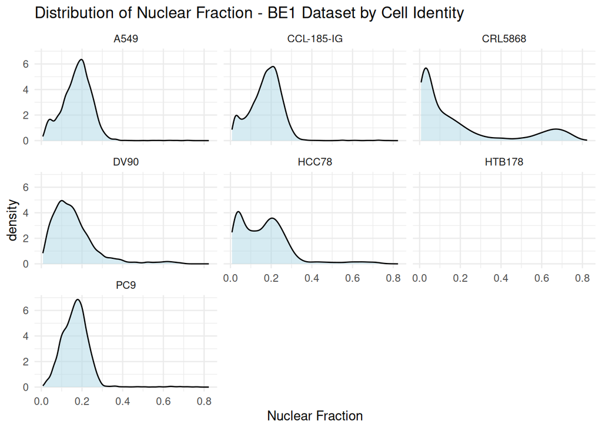

Distribution of Nuclear Fraction - BE1 Dataset by Cell Identity

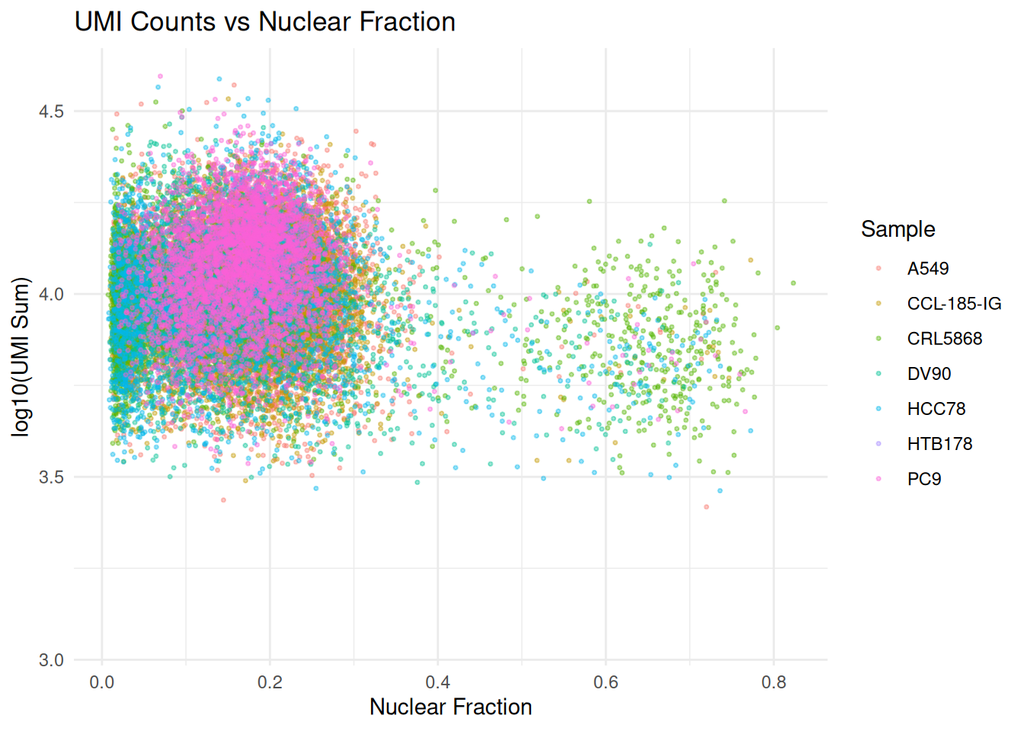

UMI Counts vs Nuclear Fraction

```r
# Primo grafico: Distribuzione di densità
p1 <- ggplot(as.data.frame(colData(sce_be1)), aes(x = nuclear_fraction)) +
  geom_density(fill = "lightblue", alpha = 0.5) +
  facet_wrap(~Sample) +
  theme_minimal() +
  labs(
    title = "Distribution of Nuclear Fraction - BE1 Dataset by Cell Identity",
    x = "Nuclear Fraction"
  )

# Secondo grafico: Scatter plot UMI vs Nuclear Fraction
p2 <- ggplot(as.data.frame(colData(sce_be1)), aes(x = nuclear_fraction, y = log10(sum), colour = Sample)) +
  geom_point(alpha = 0.4, size = 0.6) +
  theme_minimal() +
  labs(
    title = "UMI Counts vs Nuclear Fraction",
    x = "Nuclear Fraction",
    y = "log10(UMI Sum)"
  )

p1
p2
```

## Normalization and Dimensionality Reduction

We perform log-transformation on the counts, select the Top 10% Highly Variable Genes (HVGs), and compute PCA and UMAP coordinates.

```r
sce_be1 <- logNormCounts(sce_be1)
dec <- modelGeneVar(sce_be1)
hvgs <- getTopHVGs(dec, prop = 0.1)

sce_be1 <- runPCA(sce_be1, subset_row = hvgs, ncomponents = 50)
sce_be1 <- runUMAP(sce_be1, dimred = "PCA")
sce_be1
```

Let’s calculate the UMAP on the embeddings of scGPT and GeneFormer

```r
sce_be1 <- runUMAP(sce_be1, dimred = "scGPT", name = "UMAP_scGPT")
```

```r
sce_be1 <- runUMAP(sce_be1, dimred = "GeneFormer", name = "UMAP_GeneFormer")
```

```r
# Rename 'Geneformer' to 'Geneformer_V2'
reducedDimNames(sce_be1)[reducedDimNames(sce_be1) == "UMAP_embed"] <- "UMAP_scGPT"
```

### Visualizing Embeddings (PCA vs UMAP)

We compare the embedding spaces side-by-side, coloring cells by Sample and Nuclear Fraction using `patchwork`.

```r
# Cell identity - UMAP + PCA
umapsm <- plotUMAP(sce_be1, colour_by = "Sample", dimred = "UMAP") +
  theme(legend.position = "bottom") +
  labs(title = "UMAP (PCA) colored by cell identity")
pcasm  <- plotPCA(sce_be1, colour_by = "Sample") +
  theme(legend.position = "none") +
  labs(title = "PCA colored by cell identity")

# Nuclear Fraction - UMAP + PCA
umapnf <- plotUMAP(sce_be1, colour_by = "nuclear_fraction", dimred = "UMAP") +
  theme(legend.position = "bottom") +
  labs(title = "UMAP (PCA) colored by nuclear fraction")
pcanf  <- plotPCA(sce_be1, colour_by = "nuclear_fraction") +
  theme(legend.position = "none") +
  labs(title = "PCA colored by nuclear fraction")
```

#### scGPT embeddings UMAP

```r
umapgs <- plotUMAP(sce_be1, colour_by = "Sample", dimred = "UMAP_scGPT") +
  theme(legend.position = "bottom") +
  labs(title = "UMAP (scGPT) colored by cell identity")
umapgnf <- plotUMAP(sce_be1, colour_by = "nuclear_fraction", dimred = "UMAP_scGPT") +
  theme(legend.position = "bottom") +
  labs(title = "UMAP (scGPT) colored by nuclear fraction")
```

#### GeneFormer embeddings UMAP

```r
umapgfs <- plotUMAP(sce_be1, colour_by = "Sample", dimred = "UMAP_GeneFormer") +
  theme(legend.position = "bottom") +
  labs(title = "UMAP (GeneFormer) colored by cell identity")
umapgfnf <- plotUMAP(sce_be1, colour_by = "nuclear_fraction", dimred = "UMAP_GeneFormer") +
  theme(legend.position = "bottom") +
  labs(title = "UMAP (GeneFormer) colored by nuclear fraction")
```

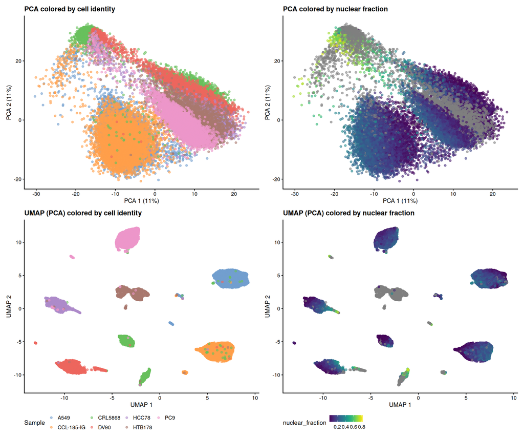

```r
(pcasm | pcanf ) / (umapsm | umapnf )
```

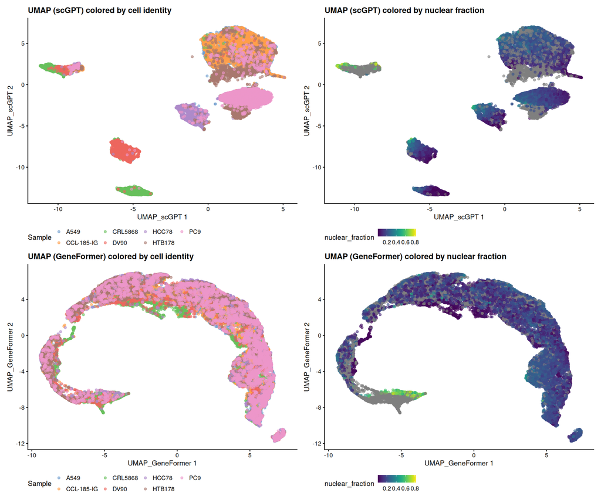

```r
(umapgs | umapgnf) / (umapgfs | umapgfnf)
```

## Focus on MALAT1 and Nuclear Fraction Relationship

We evaluate the behavior of the nuclear-retained long non-coding RNA **MALAT1** to biologically validate our nuclear fraction metric.

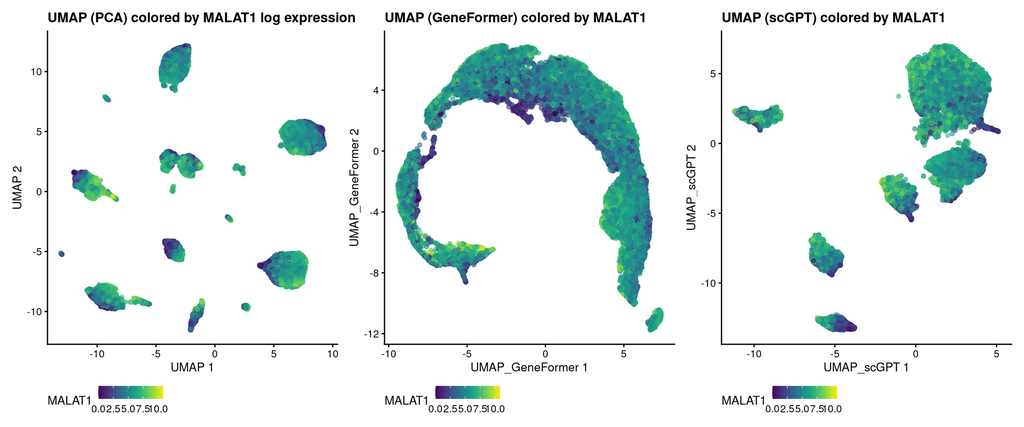

```r
umapm <- plotUMAP(sce_be1, colour_by = "MALAT1") + theme(legend.position = "bottom") +
  labs(title = "UMAP (PCA) colored by MALAT1 log expression")
umapgfm <- plotUMAP(sce_be1, colour_by = "MALAT1", dimred = "UMAP_GeneFormer") + theme(legend.position = "bottom") +
  labs(title = "UMAP (GeneFormer) colored by MALAT1")
umapgptm <- plotUMAP(sce_be1, colour_by = "MALAT1", dimred = "UMAP_scGPT") + theme(legend.position = "bottom") +
  labs(title = "UMAP (scGPT) colored by MALAT1")

# Direct comparison in reduced dimensions
umapm | umapgfm | umapgptm
```

### UMAP of scGPT embeddings

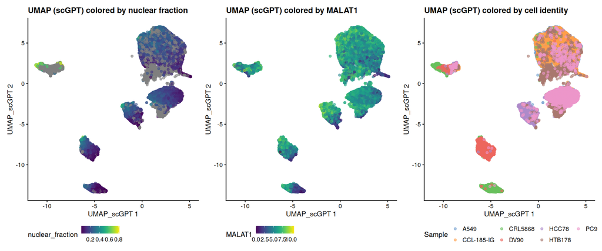

```r
umapgnf | umapgptm | umapgs
```

### UMAP of GeneFormer embeddings

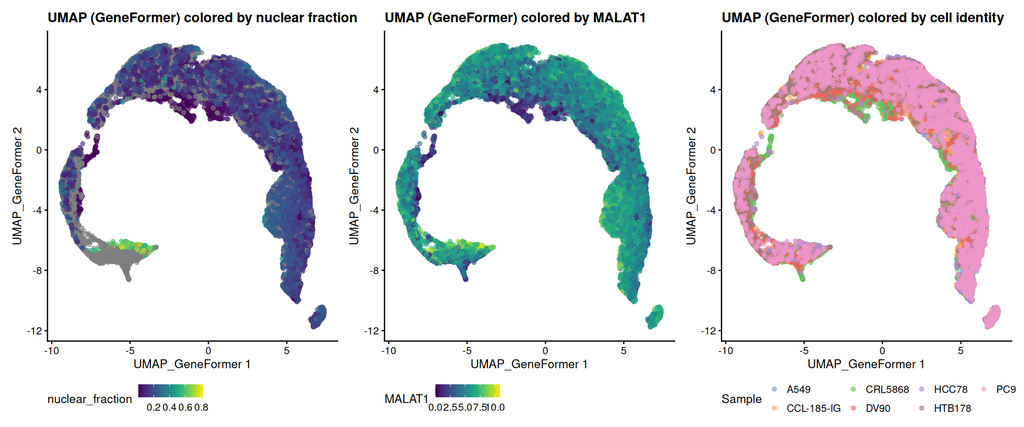

```r
umapgfnf | umapgfm | umapgfs
```

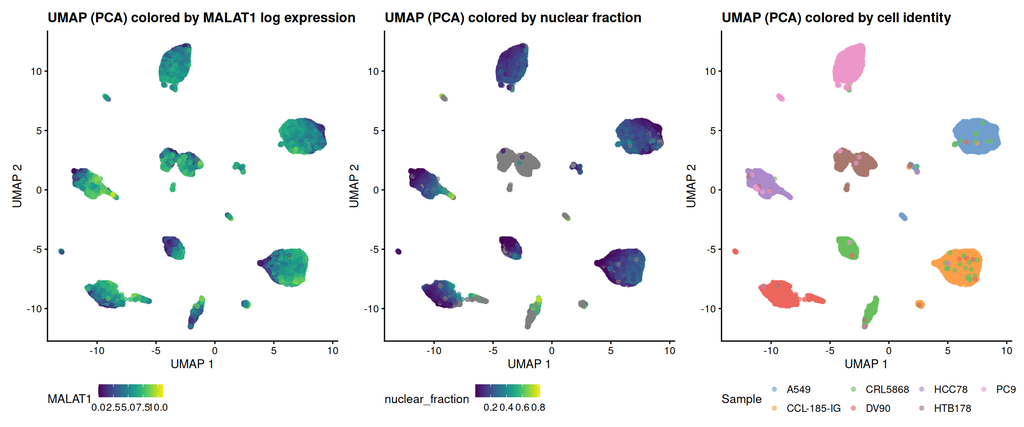

```r
umapm | umapnf | umapsm
```

### MALAT1 vs Nuclear Fraction Scatter Plot Faceted by Sample

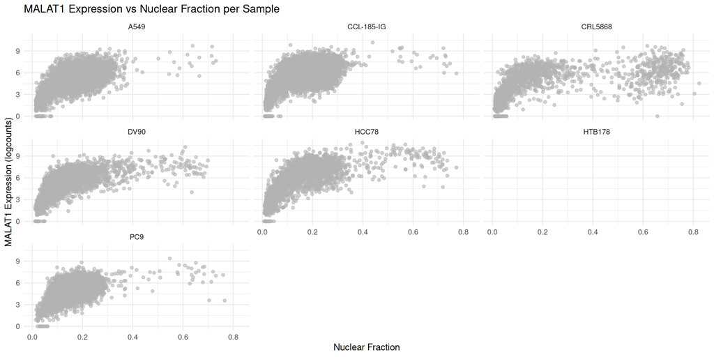

```r
plotExpression(sce_be1,
               features = "MALAT1",
               x = "nuclear_fraction",
               other_fields = "Sample",
               exprs_values = "logcounts") +
  facet_wrap(~Sample) +
  aes(color = Sample) +
  theme_minimal() +
  labs(title = "MALAT1 Expression vs Nuclear Fraction per Sample",
       x = "Nuclear Fraction",
       y = "MALAT1 Expression (logcounts)")
```

### Detecting Empty Droplets and Damaged cells with `DropletQC`

We prepare the data frame for the `DropletQC` algorithm by handling missing values (`NA`) and evaluating the empty droplet cutoff.

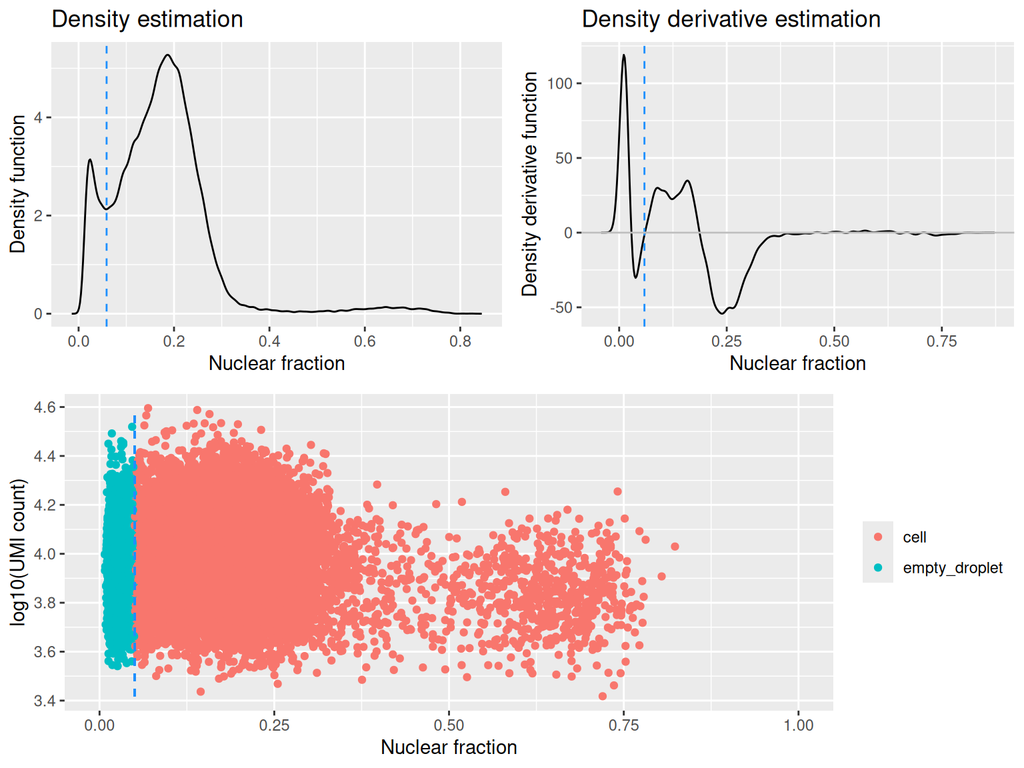

```r
nf_umi <- data.frame(
  nf = sce_be1$nuclear_fraction,
  umi = sce_be1$sum,
  Sample = sce_be1$Sample
)

rownames(nf_umi) <- colnames(sce_be1)

# Handle NA values
nf_umi <- nf_umi[!is.na(nf_umi$nf),]

# Identify empty droplets and output the diagnostic plot
cb_be1 <- identify_empty_drops(nf_umi = nf_umi, include_plot = TRUE)
```

```r
# Summary table of cell status
table(cb_be1$cell_status)
```

```
         cell empty_droplet
        21294          2575
```

## Investigation of possible association between empty droplets, cellS identity and MALAT1 gene

Add the cell status column in the coldata of sce_be1

```r
sce_be1$cell_status <- cb_be1[colnames(sce_be1), "cell_status"]
```

```r
table(sce_be1$Sample, sce_be1$cell_status)
```

```
             cell empty_droplet
  A549       6104           358
  CCL-185-IG 5467           478
  CRL5868    1221           805
  DV90       2281           265
  HCC78      2041           577
  HTB178        0             0
  PC9        4180            92
```

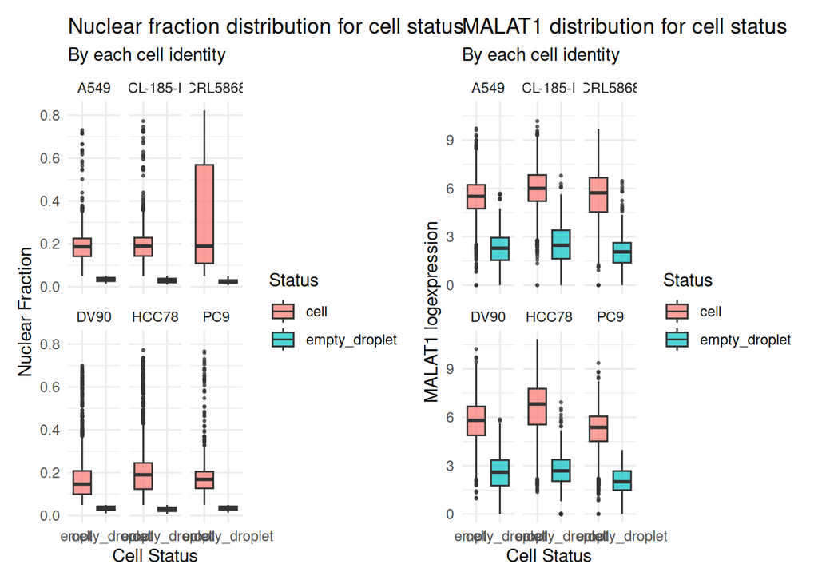

```r
p1 <- sce_be1[, !is.na(sce_be1$cell_status)] |>
  ggcells(aes(x = cell_status, y = nuclear_fraction, fill = cell_status)) +
  geom_boxplot(alpha = 0.7, outlier.size = 0.5) +  # Disegna il boxplot
  facet_wrap(~ Sample) +                           # Ora Sample è visibile!
  theme_minimal() +
  labs(
    title = "Nuclear fraction distribution for cell status",
    subtitle = "By each cell identity",
    x = "Cell Status",
    y = "Nuclear Fraction",
    fill = "Status"
  )

p2 <- sce_be1[, !is.na(sce_be1$cell_status)] |>
  ggcells(aes(x = cell_status, y = MALAT1, fill = cell_status)) +
  geom_boxplot(alpha = 0.7, outlier.size = 0.5) +
  facet_wrap(~ Sample) +
  theme_minimal() +
  labs(
    title = "MALAT1 distribution for cell status",
    subtitle = "By each cell identity",
    x = "Cell Status",
    y = "MALAT1 logexpression",
    fill = "Status"
  )

p1 | p2
```

### Damaged Cell Identification

Finally, we identify damaged cells by leveraging cell type annotations and save the finalized object.

```r
# Reorder columns
cb_be1 <- cb_be1 |>
  relocate(Sample, .after = cell_status)

# Identify damaged cells using DropletQC
cb_be1_dc <- identify_damaged_cells(cb_be1, verbose = FALSE, output_plots = TRUE)

# Final cell status summary
table(cb_be1_dc[[1]]$cell_status)
```

[output not shown]

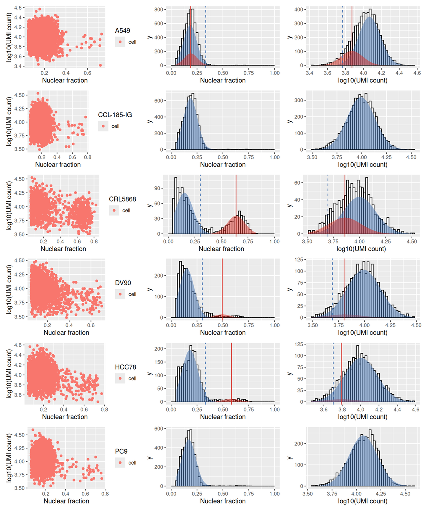

```r
# Diagnostic plots for each cell identity group
wrap_plots(cb_be1_dc[[2]], nrow = 6)
```